# Lab 2a - Network data management with statnet

Douglas Luke

July 10, 2021

## Introduction

These labs are meant to be exploratory exercises (*i.e.,* laboratories), that roughly follow the material in my Springer book, *A User’s Guide to Network Analysis.* In general, these labs will have minimal exposition, but focus on the logic of the code and output, and suggest ways to explore the material in greater depth.

This lab corresponds to Chapter 3 - Network Data Management.

```r
library(statnet)
library(UserNetR)
```

## Creating network data objects

### From matrices

Typically, network objects will be created from matrices, or from edgelists. Notice how matrices can be subsetted using indexing.

```r
netmat1 <- rbind(c(0,1,1,0,0),
                 c(0,0,1,1,0),
                 c(0,1,0,0,0),
                 c(0,0,0,0,0),
                 c(0,0,1,0,0))
class(netmat1)
```

```
## [1] "matrix" "array"
```

```r
netmat1[3,]
```

```
## [1] 0 1 0 0 0
```

```r
netmat1[,2]
```

```
## [1] 1 0 1 0 0
```

```r
netmat1[3,2]
```

```
## [1] 1
```

```r
netmat1[,]
```

```
##      [,1] [,2] [,3] [,4] [,5]
## [1,]    0    1    1    0    0
## [2,]    0    0    1    1    0
## [3,]    0    1    0    0    0
## [4,]    0    0    0    0    0
## [5,]    0    0    1    0    0
```

Q: Can you tell from this matrix whether we are going to have a directed, or non-directed network?

To create a network from a matrix, use the `network()` function. Note that if the matrix has row and column names, they will be used to name the nodes in the resulting network.

```r
rownames(netmat1) <- c("A","B","C","D","E")
colnames(netmat1) <- c("A","B","C","D","E")
net1 <- network(netmat1,matrix.type="adjacency")
class(net1)
```

```
## [1] "network"
```

```r
summary(net1)
```

```
## Network attributes:
##   vertices = 5
##   directed = TRUE
##   hyper = FALSE
##   loops = FALSE
##   multiple = FALSE
##   bipartite = FALSE
##  total edges = 6
##    missing edges = 0
##    non-missing edges = 6
##  density = 0.3
##
## Vertex attributes:
##   vertex.names:
##    character valued attribute
##    5 valid vertex names
##
## No edge attributes
##
## Network adjacency matrix:
##   A B C D E
## A 0 1 1 0 0
## B 0 0 1 1 0
## C 0 1 0 0 0
## D 0 0 0 0 0
## E 0 0 1 0 0
```

Q: What other types of matrices can `network()` handle?

E: Explore what happens if you do not set the row/column names ahead of time.

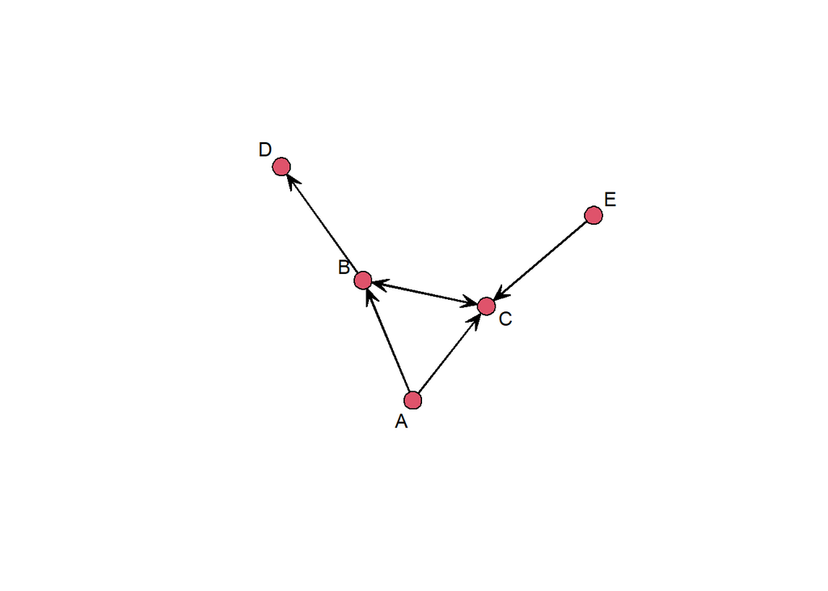

```r
gplot(net1,vertex.col=2,displaylabels=TRUE)
```

E: What happens when you use `plot` instead of `gplot`? Look at the help for these two commands to explore the differences. Start exploring ways to improve the appearance of these plots.

### From edge-lists

This still works from a matrix, but the matrix here is in the form of an edge-list.

```r
netmat2 <- rbind(c(1,2),
                 c(1,3),
                 c(2,3),
                 c(2,4),
                 c(3,2),
                 c(5,3))
net2 <- network(netmat2,matrix.type="edgelist")
network.vertex.names(net2) <- c("A","B","C","D","E")
summary(net2)
```

```
## Network attributes:
##   vertices = 5
##   directed = TRUE
##   hyper = FALSE
##   loops = FALSE
##   multiple = FALSE
##   bipartite = FALSE
##  total edges = 6
##    missing edges = 0
##    non-missing edges = 6
##  density = 0.3
##
## Vertex attributes:
##   vertex.names:
##    character valued attribute
##    5 valid vertex names
##
## No edge attributes
##
## Network adjacency matrix:
##   A B C D E
## A 0 1 1 0 0
## B 0 0 1 1 0
## C 0 1 0 0 0
## D 0 0 0 0 0
## E 0 0 1 0 0
```

E: Figure out a way to create a network from an edgelist, where the names of the nodes are included in the matrix itself. Hint: the edgelist matrix can be made of strings, not just numbers.

### Coercion functions

The power of data management in R is driven partly by the ease of ‘coercing’ data in one form into another form. Sometimes called data transformation.

```r
as.sociomatrix(net1)
```

```
##   A B C D E
## A 0 1 1 0 0
## B 0 0 1 1 0
## C 0 1 0 0 0
## D 0 0 0 0 0
## E 0 0 1 0 0
```

```r
class(as.sociomatrix(net1))
```

```
## [1] "matrix" "array"
```

```r
class(net1)
```

```
## [1] "network"
```

```r
as.edgelist(net1)
```

```
##      [,1] [,2]
## [1,]    1    2
## [2,]    1    3
## [3,]    2    3
## [4,]    2    4
## [5,]    3    2
## [6,]    5    3
## attr(,"n")
## [1] 5
## attr(,"vnames")
## [1] "A" "B" "C" "D" "E"
## attr(,"directed")
## [1] TRUE
## attr(,"bipartite")
## [1] FALSE
## attr(,"loops")
## [1] FALSE
## attr(,"class")
## [1] "matrix_edgelist" "edgelist"        "matrix"          "array"
```

Q: Is there an equivalent function for edgelists?

```r
all(as.matrix(net1) == as.sociomatrix(net1))
```

```
## [1] TRUE
```

```r
as.matrix(net1,matrix.type = "edgelist")
```

```
##      [,1] [,2]
## [1,]    1    2
## [2,]    3    2
## [3,]    1    3
## [4,]    2    3
## [5,]    5    3
## [6,]    2    4
## attr(,"n")
## [1] 5
## attr(,"vnames")
## [1] "A" "B" "C" "D" "E"
```

There is a lot of subtle stuff that goes on under the hood with data objects. (Run the following code one line at a time.)

```r
class(net1)
```

```
## [1] "network"
```

```r
net1
```

```
##  Network attributes:
##   vertices = 5
##   directed = TRUE
##   hyper = FALSE
##   loops = FALSE
##   multiple = FALSE
##   bipartite = FALSE
##   total edges= 6
##     missing edges= 0
##     non-missing edges= 6
##
##  Vertex attribute names:
##     vertex.names
##
## No edge attributes
```

```r
net1[,]
```

```
##   A B C D E
## A 0 1 1 0 0
## B 0 0 1 1 0
## C 0 1 0 0 0
## D 0 0 0 0 0
## E 0 0 1 0 0
```

```r
net1[3,]
```

```
## [1] 0 1 0 0 0
```

```r
net1[,2]
```

```
## [1] 1 0 1 0 0
```

```r
net1[3,2]
```

```
## [1] 1
```

E: This looks a lot like how we were earlier able to extract parts of a matrix. How does R know how to do this with a network object? Hint: Use the `class()` function to see what is being returned.

## Managing node and tie attributes

### Node attributes

One of the reasons we use network objects, and not just raw matrices (sociomatrices or edgelists), is that network objects can also store information about the nodes and/or ties in the object itself. This facilitates network analysis and visualization.

```r
set.vertex.attribute(net1, "gender", c("F","F","M","F","M"))
net1 %v% "alldeg" <- degree(net1)
list.vertex.attributes(net1)
```

```
## [1] "alldeg"       "gender"       "na"           "vertex.names"
```

```r
summary(net1)
```

```
## Network attributes:
##   vertices = 5
##   directed = TRUE
##   hyper = FALSE
##   loops = FALSE
##   multiple = FALSE
##   bipartite = FALSE
##  total edges = 6
##    missing edges = 0
##    non-missing edges = 6
##  density = 0.3
##
## Vertex attributes:
##
##  alldeg:
##    numeric valued attribute
##    attribute summary:
##    Min. 1st Qu.  Median    Mean 3rd Qu.    Max.
##     1.0     1.0     2.0     2.4     4.0     4.0
##
##  gender:
##    character valued attribute
##    attribute summary:
## F M
## 3 2
##   vertex.names:
##    character valued attribute
##    5 valid vertex names
##
## No edge attributes
##
## Network adjacency matrix:
##   A B C D E
## A 0 1 1 0 0
## B 0 0 1 1 0
## C 0 1 0 0 0
## D 0 0 0 0 0
## E 0 0 1 0 0
```

```r
net1 %v% "vertex.names" <- c("Susan","Alina","Doug","Helen","Andrew")
net1 %v% "vertex.names"
```

```
## [1] "Susan"  "Alina"  "Doug"   "Helen"  "Andrew"
```

Make sure you understand that the first two lines in the code above demonstrate two equivalent ways to set node attributes. This syntax can also be used to view the node attributes (not just to set them).

```r
net1 %v% "alldeg"
```

```
## [1] 2 4 4 1 1
```

*Important point that is not emphasized in the book!*

When setting the node attributes, especially when bringing in attribute data from an external source such as a data.frame, you must make sure that the attribute data use the same order of nodes as the network object.

So, when creating the network object, think carefully about what the right sort order is.

Note that for a `statnet` network object, the network will have a `vertex.names` node attribute that can be examined to see the node order.

```r
net1 %v% "vertex.names"
```

```
## [1] "Susan"  "Alina"  "Doug"   "Helen"  "Andrew"
```

E: These examples are easy to follow for a small, artificial network. Take some time to use these procedures on one of the larger networks included in `UserNetR`. For example, the following code shows how to look only at the first five node names (to check node order) from the `DHHS` network.

```r
data(DHHS)
(DHHS %v% "vertex.names")[1:5]
```

```
## [1] "ACF-1"  "ACF-2"  "AHRQ-1" "AHRQ-2" "AHRQ-3"
```

Q: What happens if you leave out the parentheses above? What happens if you drop the brackets? Any ideas what is happening here?

### Tie attributes

Less commonly needed, but still important to understand. Harder to work with, because it’s harder to see (and manipulate) the underlying tie order.

Here we can see how to create a valued network from a sociomatrix.

```r
netval1 <- rbind(c(0,2,3,0,0),
                 c(0,0,3,1,0),
                 c(0,1,0,0,0),
                 c(0,0,0,0,0),
                 c(0,0,2,0,0))
netval1 <- network(netval1,matrix.type="adjacency",
                   ignore.eval=FALSE,names.eval="like")
network.vertex.names(netval1) <- c("A","B","C","D","E")
list.edge.attributes(netval1)
```

```
## [1] "like" "na"
```

```r
get.edge.attribute(netval1, "like")
```

```
## [1] 2 1 3 3 2 1
```

```r
netval1 %e% "like"
```

```
## [1] 2 1 3 3 2 1
```

E: Figure out how to plot the previous network using the tie strength attribute (`like`) to adjust the thickness of the lines.

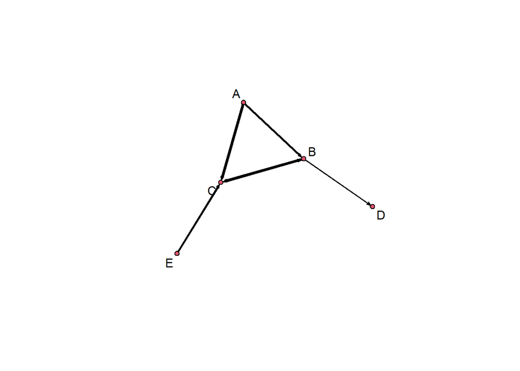

```r
thick <- ((netval1 %e% "like")*4)-3
plot(netval1,vertex.col=2,displaylabels=TRUE,edge.lwd=thick)
```

## Importing network data

*Possibly do class exercise.*

```r
netmat3 <- rbind(c("A","B"),
                 c("A","C"),
                 c("B","C"),
                 c("B","D"),
                 c("C","B"),
                 c("E","C"))
net.df <- data.frame(netmat3)
net.df
```

```
##   X1 X2
## 1  A  B
## 2  A  C
## 3  B  C
## 4  B  D
## 5  C  B
## 6  E  C
```

```r
write.csv(net.df, file = "MyData.csv",
          row.names = FALSE)
net.edge <- read.csv(file="MyData.csv")
net_import <- network(net.edge,
                      matrix.type="edgelist")
summary(net_import)
```

```
## Network attributes:
##   vertices = 5
##   directed = TRUE
##   hyper = FALSE
##   loops = FALSE
##   multiple = FALSE
##   bipartite = FALSE
##  total edges = 6
##    missing edges = 0
##    non-missing edges = 6
##  density = 0.3
##
## Vertex attributes:
##   vertex.names:
##    character valued attribute
##    5 valid vertex names
##
## No edge attributes
##
## Network adjacency matrix:
##   A B C E D
## A 0 1 1 0 0
## B 0 0 1 0 1
## C 0 1 0 0 0
## E 0 0 1 0 0
## D 0 0 0 0 0
```

```r
gden(net_import)
```

```
## [1] 0.3
```

## Common data management tasks

### Filtering on node (or tie) attributes

```r
net1 %v% "gender"
```

```
## [1] "F" "F" "M" "F" "M"
```

```r
n1F <- get.inducedSubgraph(net1,
            which(net1 %v% "gender" == "F"))
n1F[,]
```

```
##       Susan Alina Helen
## Susan     0     1     0
## Alina     0     0     1
## Helen     0     0     0
```

E: Look at the help file for `get.inducedSubgraph` and `which` to figure out why the above code works.

### Removing isolates

A very common task is to filter out isolates (nodes with degree=0; no ties). Note that this is just a special type of filtering. So, can use the same approach as above.

Here we use the ICTS dataset.

```r
data(ICTS_G10)
summary(ICTS_G10,print.adj = FALSE)
```

```
## Network attributes:
##   vertices = 493
##   directed = FALSE
##   hyper = FALSE
##   loops = FALSE
##   multiple = FALSE
##   bipartite = FALSE
##   title = G10_Pajek
##  total edges = 1359
##    missing edges = 0
##    non-missing edges = 1359
##  density = 0.01120566
##
## Vertex attributes:
##
##  DiscCol:
##    numeric valued attribute
##    attribute summary:
##    Min. 1st Qu.  Median    Mean 3rd Qu.    Max.
##    1100    3600    6500    5231    6500    8888
##
##  DiscExp:
##    numeric valued attribute
##    attribute summary:
##    Min. 1st Qu.  Median    Mean 3rd Qu.    Max.
##    1100    2800    6540    5067    6910    8888
##   vertex.names:
##    character valued attribute
##    493 valid vertex names
##
##  year:
##    numeric valued attribute
##    attribute summary:
##    Min. 1st Qu.  Median    Mean 3rd Qu.    Max.
##    2008    2008    2009    2009    2010    2010
##
## No edge attributes
```

```r
table(degree(ICTS_G10,gmode="graph"))
```

```
##
##  0  1  2  3  4  5  6  7  8  9 10 11 12 13 14 15 16 17 18 19 20 21 22 23 24 25
## 96 82 56 43 32 24 21 18 15  9 12  7  4  7  9  2  4  9 10  4  4  7  2  3  1  1
## 26 27 28 29 30 32 33 37 39
##  1  1  1  2  2  1  1  1  1
```

```r
degree(ICTS_G10,gmode="graph")
```

```
##   [1] 39 30  6  7 19  8  2 15  2 21  2  4 37  2  4  7  7  0  7  9  5  0 10  1  4
##  [26]  3  4 11  1 17 16 21  1  2  0 24  1 30  2  1 23  4  2  1  1  7  0  2  8 10
##  [51] 20  4  1 11  4  1  0 14 29  0 18  4  6  1  1  3  6 10 13 23 16 22  5  3  3
##  [76] 11  2  1  1  6  5  7 14  1 25  5  0  1  1  4  0  7  6  5  1  6  5  2  4  4
## [101] 10  6  1  3  8 18  5  2 23  3 18 21  2  3 28 29  2 21  0 14 13 14 26  5  3
## [126]  6  0  1  3  8  9 20  1 13 13  3  1  2  8 17  1 14 22  5  3  6  0  4  3  7
## [151]  0  8 17 19  3  0 21 18  3  0 18  2  1  1 14 15  1 18  0  1  0  1  4  1  3
## [176]  0  0  6  6  1 19  2  1  7 14  0 17 17  2  0  1  3  7  4  2  1  1  2  0  4
## [201] 16  8  0  3  9  8  5 14  7 18 32  0  0  0  5  2  3  3 13  2  9  4  7  4  2
## [226]  6  3  2 21  0  8  2  0  1  0  7  2 13  6  2  5  0  2  3  0  1  2 14  1  0
## [251]  1  0  9 21  0  1  7  3  5 12  1  0 12  7  7  1  5 13  3 10  3  4  1  3  0
## [276] 10  3  5  2  0  2  2  1  2 10 18  6  8 27  6  2  0  2  1  9  3  6 12  1  1
## [301]  2  8  1  2  1  0  0  0  0  0  2  0  5  5  2  0 18  3  0  0  8  2 20 17  0
## [326]  4  1  5  0  4  0  2  4  1 10 11  1  8  5  4 11  4  7  1  0  2  3  3  0  6
## [351] 33  5  1  6  1  0  2  1 19  2  5  0  0  0  1  1  8  0  6  1 10  2 10 17  2
## [376]  1  0  9  1  1  0  4  1  0  3  1  0  8  1  2  0  0  0  2  1  1  0  3  0  0
## [401]  1  0  3  0  0  4  0  6  1 10  3  1  2  3 17  2  2  1  9  3  0  5 18  4  2
## [426] 16  2  0  0 11  0  0  1  1  2  5  1  1  1  1  0  5 17  0  0  0  1  4  0  4
## [451]  1  0  0  1  9  3  1  0  0  1  0  0 10 11  0  6  0  0  0  4  3  3  4  2  0
## [476]  3  3 12  4  2  0  3  0  0  7  3 20  0  1  0  1  4  2
```

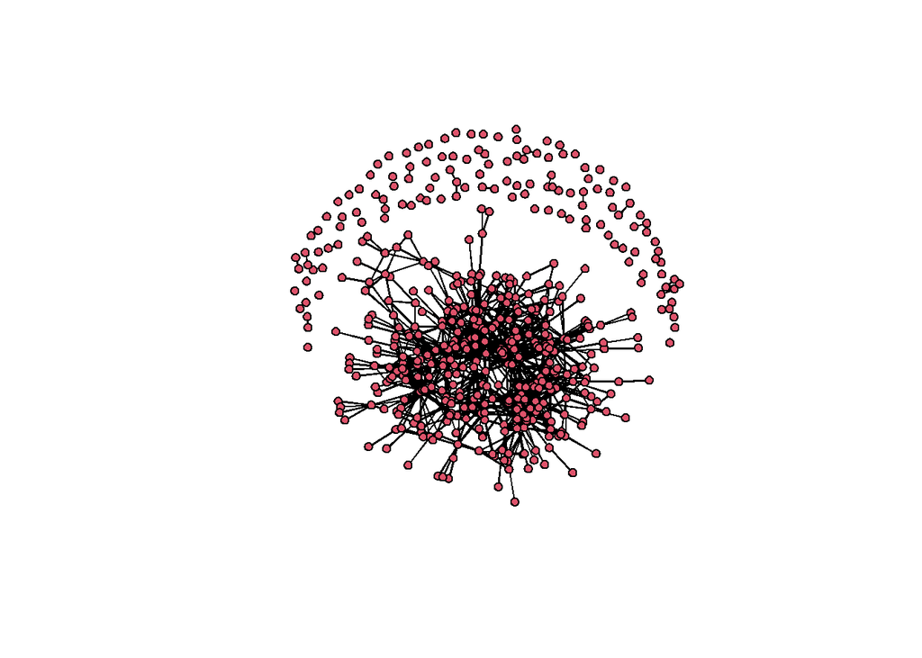

```r
plot(ICTS_G10)
```

Q: What happens above if you drop out the `gmode` option?

```r
ICTS2 <- get.inducedSubgraph(ICTS_G10,
            which(degree(ICTS_G10) > 0))
table(degree(ICTS2,gmode="graph"))
```

```
##
##  1  2  3  4  5  6  7  8  9 10 11 12 13 14 15 16 17 18 19 20 21 22 23 24 25 26
## 82 56 43 32 24 21 18 15  9 12  7  4  7  9  2  4  9 10  4  4  7  2  3  1  1  1
## 27 28 29 30 32 33 37 39
##  1  1  2  2  1  1  1  1
```

```r
network.size(ICTS_G10)
```

```
## [1] 493
```

```r
network.size(ICTS2)
```

```
## [1] 397
```

Q: Why does the following code not work?

```r
ICTS2 <- get.inducedSubgraph(ICTS_G10,
            which(degree(ICTS_G10 > 0)))
```

In the book I highlight the use of the `isolates()` function. Now I think the above approach is much easier.

### More detailed example

Look at the DHHS network.

```r
data(DHHS)
d <- DHHS
gden(d)
```

```
## [1] 0.312369
```

The following code is taken directly from my book.

```r
d.val <- as.sociomatrix(d,attrname="collab")
d.val[d.val < 3] <- 0
d.filt <- as.network(d.val, directed=FALSE,
                    matrix.type="a",ignore.eval=FALSE,
                    names.eval="collab")
```

This approach to filtering leaves the same number of nodes, but density is now much lower.

```r
network.size(d)
```

```
## [1] 54
```

```r
gden(d)
```

```
## [1] 0.312369
```

```r
network.size(d.filt)
```

```
## [1] 54
```

```r
gden(d.filt)
```

```
## [1] 0.1208945
```

Here is an alternative way to filter a graph based on tie values. Note that this code is much simpler.

```r
table(d %e%"collab")
```

```
##
##   1   2   3   4
## 163 111  94  79
```

```r
d.filt2 <- get.inducedSubgraph(d,
                          eid=which(d %e% "collab" > 2))
table(d.filt2 %e%"collab")
```

```
##
##  3  4
## 94 79
```

```r
network.size(d.filt2)
```

```
## [1] 48
```

```r
gden(d.filt2)
```

```
## [1] 0.1533688
```

*However, this approach does not filter the network in exactly the same way!* The new filtered network has six fewer nodes than the first approach (and thus, a higher density). Why is this? The key is in the following line from the help file for `get.inducedSubgraph`:

“When eid is specified, the v and alters argument will be ignored and the subgraph induced by the specified edges *and their incident vertices* will be returned.”

So, the first method (described in my book), filters by dropping edges but retaining all nodes. The second approach filters by first selecting the edges, and then including only the nodes incident to those edges.

## Symmetrizing a network

This means turning a directed network into a non-directed network.

```r
net1mat <- symmetrize(net1,rule="weak")
net1mat
```

```
##      [,1] [,2] [,3] [,4] [,5]
## [1,]    0    1    1    0    0
## [2,]    1    0    1    1    0
## [3,]    1    1    0    0    1
## [4,]    0    1    0    0    0
## [5,]    0    0    1    0    0
```

```r
net1symm <- network(net1mat,matrix.type="adjacency")
network.vertex.names(net1symm) <- c("A","B","C","D","E")
summary(net1symm)
```

```
## Network attributes:
##   vertices = 5
##   directed = TRUE
##   hyper = FALSE
##   loops = FALSE
##   multiple = FALSE
##   bipartite = FALSE
##  total edges = 10
##    missing edges = 0
##    non-missing edges = 10
##  density = 0.5
##
## Vertex attributes:
##   vertex.names:
##    character valued attribute
##    5 valid vertex names
##
## No edge attributes
##
## Network adjacency matrix:
##   A B C D E
## A 0 1 1 0 0
## B 1 0 1 1 0
## C 1 1 0 0 1
## D 0 1 0 0 0
## E 0 0 1 0 0
```

Q: What do the various rule options mean for the `symmetrize()` function, and when might you use each of them?

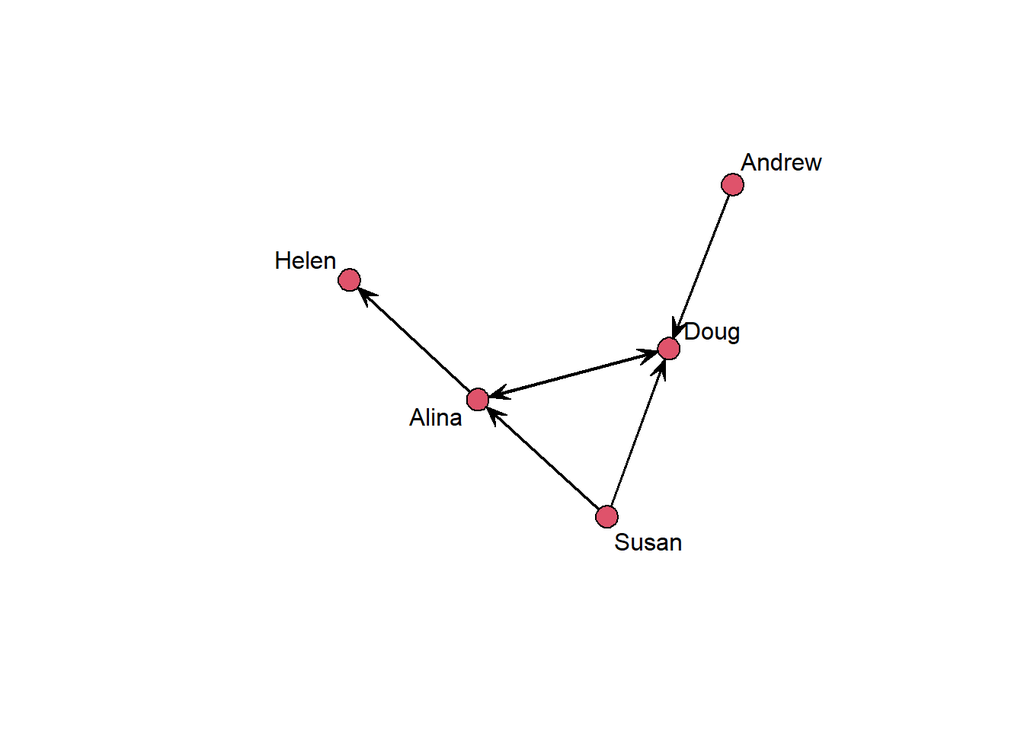

```r
gplot(net1,vertex.col=2,displaylabels=TRUE)
```

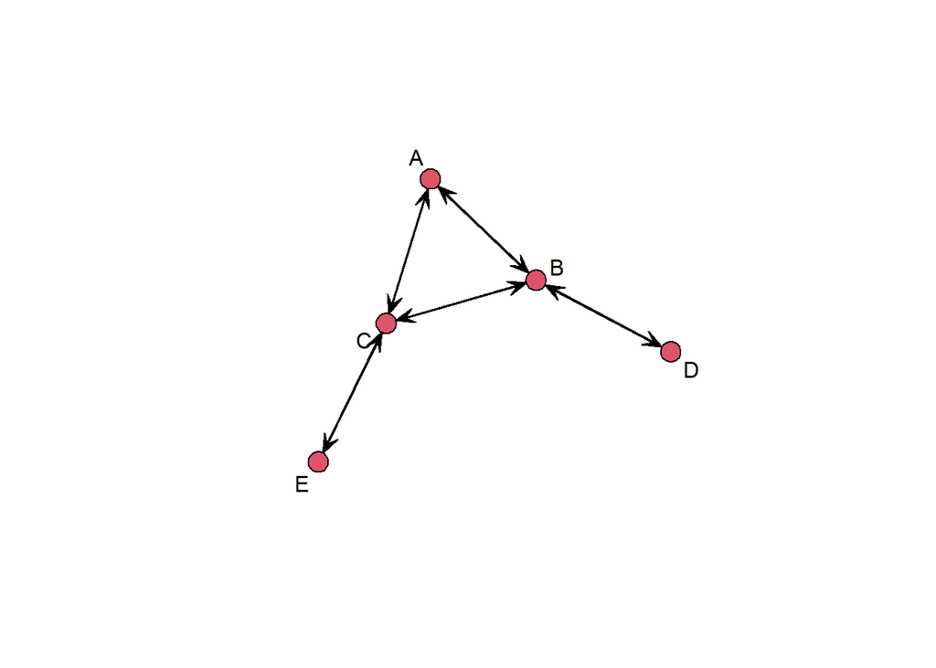

```r
gplot(net1symm,vertex.col=2,displaylabels=TRUE)
```

E: Is the above plot what you expected to see? Why are arrows plotted? How could you fix this?